# Procesamiento de lenguaje natural

Más sobre preprocesamiento

Algunas técnicas de vectorización

Continuando con lo último visto en la clase anterior, cargamos el dataframe de nuestro texto preprocesado:

```python
import pandas as pd

df_lematizador = pd.read_csv('https://luisapaez.github.io/Teoria_Galois/Texto_procesado.csv')

# Consideraremos solo las primeras 2 columnas
df = df_lematizador[['Página', 'Párrafos']]
df
```

|  | Página | Párrafos |
| --- | --- | --- |
| 0 | 1 | dune |
| 1 | 1 | beginning time taking delicate care balances c... |
| 2 | 1 | manual muad dib princess irulan |
| 3 | 1 | week departure arrakis final scurrying reached... |
| 4 | 1 | warm night castle caladan ancient pile stone s... |
| ... | ... | ... |
| 7602 | 591 | part publication may reproduced stored retriev... |
| 7603 | 591 | means without prior permission writing publish... |
| 7604 | 591 | circulated form binding cover published withou... |
| 7605 | 591 | condition including condition imposed subseque... |
| 7606 | 591 | www orionbooks co uk |

7607 rows × 2 columns

Después cargamos las librerías que ocuparemos

```python
import re
import nltk
from collections import Counter
import contractions
import pandas as pd
from nltk.corpus import stopwords
from nltk.tokenize import word_tokenize
from nltk.stem import WordNetLemmatizer
nltk.download('wordnet')

# Consideramos las stopswords del idioma ingles
stop_words = set(stopwords.words('english'))
```

Y resumiremos el proceso de preprocesamiento que hicimos en la clase anterior mediante la siguiente función:

```python
def clean_string(string):
    # Utilizaremos el conjunto de stopwords creado antes
    global stop_words
    # Consideramos solo los caracteres que son alfanumericos
    a = re.sub(r'[\W_]+',' ',
               # Quitamos las contracciones posibles de las palabras.
               # Del string en cuestion (palabras), quitamos los saltos de linea
               # y los espacio-s-espacio
               contractions.fix(string.replace('\n',' '))).replace(' s ',' ').lower()
    # Instanciamos el lematizador
    lemmatizer = WordNetLemmatizer()
    # Lista auxiliar
    lemmatization = []
    # Dividimos las palabras de string
    for k in a.split():
        # lematizamos cada palabra
        lemmatization.append(lemmatizer.lemmatize(k))
    # Unimos las palabras lematizadas en un solo string
    a = ' '.join(lemmatization)

    # Lista auxiliar
    text = []
    # Tokenizamos el string _a_ lematizado
    for k in word_tokenize(a):
        # quitamos las palabras vacias
        if k not in stop_words:
            # Agregamos las palabras no vacias a la lista auxiliar text
            text.append(k)
    # Unimos de nuevo cada palabra que es no vacia (no stopword) en un
    # solo string
    a = ' '.join(text)
    return a
```

Por ejemplo:

```python
clean_string("Hello, I'm Saul Goodman. I'll eat cookies")
```

```
'hello saul goodman eat cooky'
```

```python
cad = """Zipf's law is an empirical law, formulated using mathematical statistics,
named after the linguist George Kingsley Zipf, who first proposed it."""
clean_string(cad)
```

```
'zipf law empirical law formulated using mathematical statistic named linguist george kingsley zipf first proposed'
```

Por otro lado, retomando nuestro dataframe `dt` procederemos a tokenizar cada párrafo, para lo cual

```python
# Creamos una nueva columna en la cual dividimos cada parrafo por
# palabras
df['Senteces_in_tokens'] = df['Párrafos'].apply(lambda x: x.split())
```

[output not shown]

Vemos que algunos valores de la columna `Párrafos` son del tipo flotante. Para arreglar dicho problema:

```python
# Consideraremos solo las filas de nuestro dataframe que sea del tipo str
df = df[df['Párrafos'].apply(lambda x: True if type(x)==str else False)]
# Creamos una nueva columna en la cual dividimos cada parrafo por
# palabras
df['Senteces_in_tokens'] = df['Párrafos'].apply(lambda x: x.split())
# Veamos:
df
```

|  | Página | Párrafos | Senteces_in_tokens |
| --- | --- | --- | --- |
| 0 | 1 | dune | [dune] |
| 1 | 1 | beginning time taking delicate care balances c... | [beginning, time, taking, delicate, care, bala... |
| 2 | 1 | manual muad dib princess irulan | [manual, muad, dib, princess, irulan] |
| 3 | 1 | week departure arrakis final scurrying reached... | [week, departure, arrakis, final, scurrying, r... |
| 4 | 1 | warm night castle caladan ancient pile stone s... | [warm, night, castle, caladan, ancient, pile, ... |
| ... | ... | ... | ... |
| 7602 | 591 | part publication may reproduced stored retriev... | [part, publication, may, reproduced, stored, r... |
| 7603 | 591 | means without prior permission writing publish... | [means, without, prior, permission, writing, p... |
| 7604 | 591 | circulated form binding cover published withou... | [circulated, form, binding, cover, published, ... |
| 7605 | 591 | condition including condition imposed subseque... | [condition, including, condition, imposed, sub... |
| 7606 | 591 | www orionbooks co uk | [www, orionbooks, co, uk] |

7542 rows × 3 columns

Ahora, agregamos una nueva columna referente a la longitud de cada lista de los Párrafos tokenizados:

```python
df['Longitud'] = df['Senteces_in_tokens'].apply(lambda x: len(x))
df
```

|  | Página | Párrafos | Senteces_in_tokens | Longitud |
| --- | --- | --- | --- | --- |
| 0 | 1 | dune | [dune] | 1 |
| 1 | 1 | beginning time taking delicate care balances c... | [beginning, time, taking, delicate, care, bala... | 52 |
| 2 | 1 | manual muad dib princess irulan | [manual, muad, dib, princess, irulan] | 5 |
| 3 | 1 | week departure arrakis final scurrying reached... | [week, departure, arrakis, final, scurrying, r... | 16 |
| 4 | 1 | warm night castle caladan ancient pile stone s... | [warm, night, castle, caladan, ancient, pile, ... | 21 |
| ... | ... | ... | ... | ... |
| 7602 | 591 | part publication may reproduced stored retriev... | [part, publication, may, reproduced, stored, r... | 9 |
| 7603 | 591 | means without prior permission writing publish... | [means, without, prior, permission, writing, p... | 7 |
| 7604 | 591 | circulated form binding cover published withou... | [circulated, form, binding, cover, published, ... | 7 |
| 7605 | 591 | condition including condition imposed subseque... | [condition, including, condition, imposed, sub... | 6 |
| 7606 | 591 | www orionbooks co uk | [www, orionbooks, co, uk] | 4 |

7542 rows × 4 columns

## Más sobre preprocesamiento

Después, vemos un histograma con la cantidad de palabras que podemos encontrar en cada párrafo con su respectiva frecuencia

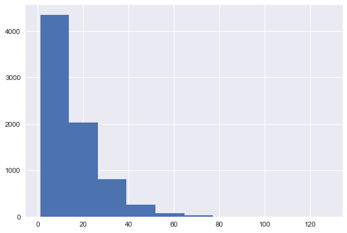

```python
import matplotlib.pyplot as plt
# Configuramos un estilo de graficacion
plt.style.use("seaborn")

df['Longitud'].hist()
plt.show()
```

y vemos entonces su distribución. Es importante dado que muchos algorítmos con los cuales podemos estar trabajando tienen cierta cantidad de entradas, esto es, no pueden trabajar con una cantidad arbitraria de palabras. Así, es necesario realizar una normalización sobre el número de palabras de los documentos. Para lo cual consideremos la siguiente información

```python
df['Longitud'].describe()
```

```
count    7542.000000
mean       14.270883
std        12.512122
min         1.000000
25%         5.000000
50%         9.000000
75%        21.000000
max       128.000000
Name: Longitud, dtype: float64
```

de donde tomaremos $\frac{\sigma}{2}\approx 6$ y la media de aproximadamente 15, para así realizar la normalización. Antes de ello definamos la siguiente función

```python
import numpy as np

def normal(x, media, desviacion, top):
    # top: tamagnio maximo
    y = top * np.exp(-((x-media)/desviacion) * ((x-media)/desviacion) * 0.5)
    return y
```

donde, por ejemplo, para documentos que tengan 15 palabras le asignaremos la frecuencia obtenida en el cálculo proveniente de la variable `y`, realizando así un tipo de extrapolación de las frecuencias de las palabras en nuetro documento. Por ejemplo para un documento con 15 palabras, una media de 15, una desviación estándar de 5 y un tope (valor máximo posible), obtemos que la frecuencia normalizada sería de

```python
normal(15, 15, 5, 160)
```

```
160.0
```

Posteriormente realizaremos la agrupación por grupos dados en la columna *Longitud*, esto es, si por ejemplo dos párrafos tiene el mismo número de elementos en la lista tokenizada, digamos 23, entonces éstos serán considerados en el grupo 23 y así para el resto de los párrafos. Mediante lo siguiente

```python
# Creamos las clases
df_class = df.groupby('Longitud')
df_class
```

```
<pandas.core.groupby.generic.DataFrameGroupBy object at 0x000002B3CD661790>
```

obtenemos clases, por ejemplo la clase 23 referente a la longitud 23 para la lista de párrafos tokenizados, y cada clase tendrá asociado, prácticamente, un dataframe. Así, si tomamos por ejemplo la clase 1 y calculamos

```python
print(normal(1, 15, 5, 160))
print(round(normal(1, 15, 5, 160)))
```

```
3.1745751590992475
3
```

entonces sería suficiente que tomaramos 3 documentos cuya longitud sea 1. Otro ejemplo

```python
print(normal(2, 15, 5, 160))
print(round(normal(2, 15, 5, 160)))
```

```
5.447592757535893
5
```

entonces sería suficiente que tomaramos 5 documentos cuya longitud sea 2, etcétera. Continuando

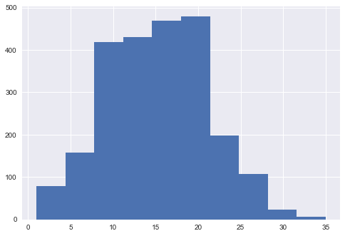

```python
# Creamos un dataframe vacio
new_data_frame = pd.DataFrame()

# Interamos sobre df_class
for classes, dataframe in df_class:
    # Obtenemos el numero de documentos que debemos tomar por cada clase
    sample_size = round(normal(classes, 15, 6, 160))
    # Numero de filas del dataframe en cuestion
    size_fram = dataframe.shape[0]
    # Si el numero de filas es mayor al numero de documentos a tomar
    # entonces iremos apilando los dataframes, donde tomamos el numero de
    # documentos dados por el numero sample_size del dataframe  _dataframe_
    if size_fram > sample_size:
        new_data_frame = pd.concat([new_data_frame, dataframe.sample(sample_size)], axis=0)
    # Si tenemos menos filas que documentos que debemos tomar, entonces simplemente
    # tomamos todas las filas de dicho dataframe
    else:
        new_data_frame = pd.concat([new_data_frame, dataframe], axis=0)

# Graficamos
new_data_frame['Longitud'].hist()
plt.show()
```

Podemos mejorar la normalización si ajustamos a una desviación estándar de 5

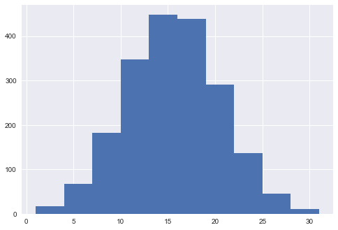

```python
# Creamos un dataframe vacio
new_data_frame = pd.DataFrame()

# Interamos sobre df_class
for classes, dataframe in df_class:
    #
    sample_size = round(normal(classes,15,5,160))
    size_fram = dataframe.shape[0]

    if size_fram > sample_size:
        new_data_frame = pd.concat([new_data_frame, dataframe.sample(sample_size)], axis=0)
    else:
        new_data_frame = pd.concat([new_data_frame, dataframe], axis=0)

# Graficamos
new_data_frame['Longitud'].hist()
plt.show()
```

con lo cual tenemos una distribución más simétrica. Se coloca el valor de 160 a partir de observar que

```python
df[df['Longitud'] == 15].shape[0]
```

```
179
```

donde para la media de longitudes, se tiene una longitud de 179, siendo así que disminuyendo un poco dicho valor consideramos el 160 como una aproximación.

```python
new_data_frame
```

[output not shown]

## Algunas técnicas de vectorización

En la sesión pasada efecutamos la vectorización de cada uno de nuestros documentos. En este caso ocuparemos otra técnica mediante `CountVectorizer` de la librería Sklearn

```python
# Realizamos la importacion necesaria
from sklearn.feature_extraction.text import CountVectorizer, TfidfVectorizer
```

Definimos el corpus

```python
corpus = df['Párrafos'].to_list()
```

Una vez definido el corpus proseguimos a vectorizarlo mediante `CountVectorizer`

```python
# Instanciamos
vectorizer = CountVectorizer()

# Ajustamos la vectorizacion al corpus definido antes
vectorizer.fit(corpus)
```

```
CountVectorizer()
```

donde el ajuste se refiere a la asociación de un vector para cada elemento del corpus. Después, calcularemos cada uno de dichos vectores para los párrafos de nuestro documento

```python
df['CountVectorizer']=df['Párrafos'].apply(lambda x: np.array(vectorizer.transform([x]).todense())[0])
df
```

|  | Página | Párrafos | Senteces_in_tokens | Longitud | CountVectorizer |
| --- | --- | --- | --- | --- | --- |
| 0 | 1 | dune | [dune] | 1 | [0, 0, 0, 0, 0, 0, 0, 0, 0, 0, 0, 0, 0, 0, 0, ... |
| 1 | 1 | beginning time taking delicate care balances c... | [beginning, time, taking, delicate, care, bala... | 52 | [0, 0, 0, 0, 0, 0, 0, 0, 0, 0, 0, 0, 0, 0, 0, ... |
| 2 | 1 | manual muad dib princess irulan | [manual, muad, dib, princess, irulan] | 5 | [0, 0, 0, 0, 0, 0, 0, 0, 0, 0, 0, 0, 0, 0, 0, ... |
| 3 | 1 | week departure arrakis final scurrying reached... | [week, departure, arrakis, final, scurrying, r... | 16 | [0, 0, 0, 0, 0, 0, 0, 0, 0, 0, 0, 0, 0, 0, 0, ... |
| 4 | 1 | warm night castle caladan ancient pile stone s... | [warm, night, castle, caladan, ancient, pile, ... | 21 | [0, 0, 0, 0, 0, 0, 0, 0, 0, 0, 0, 0, 0, 0, 0, ... |
| ... | ... | ... | ... | ... | ... |
| 7602 | 591 | part publication may reproduced stored retriev... | [part, publication, may, reproduced, stored, r... | 9 | [0, 0, 0, 0, 0, 0, 0, 0, 0, 0, 0, 0, 0, 0, 0, ... |
| 7603 | 591 | means without prior permission writing publish... | [means, without, prior, permission, writing, p... | 7 | [0, 0, 0, 0, 0, 0, 0, 0, 0, 0, 0, 0, 0, 0, 0, ... |
| 7604 | 591 | circulated form binding cover published withou... | [circulated, form, binding, cover, published, ... | 7 | [0, 0, 0, 0, 0, 0, 0, 0, 0, 0, 0, 0, 0, 0, 0, ... |
| 7605 | 591 | condition including condition imposed subseque... | [condition, including, condition, imposed, sub... | 6 | [0, 0, 0, 0, 0, 0, 0, 0, 0, 0, 0, 0, 0, 0, 0, ... |
| 7606 | 591 | www orionbooks co uk | [www, orionbooks, co, uk] | 4 | [0, 0, 0, 0, 0, 0, 0, 0, 0, 0, 0, 0, 0, 0, 0, ... |

7542 rows × 5 columns

```python
# Veamos la dimension de un vector obtenido
df['CountVectorizer'].iloc[4].shape
```

```
(11960,)
```

Indaguemos más a detalle el vector obtenido en la fila 4:

```python
# Convertimos a una lista el vector referente de la fila 4
vector_sentence = list(df['CountVectorizer'].iloc[4])
# Parrafo en dicha fila
print(df['Párrafos'].iloc[4])
print('--------Vectorizer--------')
# Veamos las entradas no nulas de dicho vector
print([(j,vector_sentence[j]) for j in range(len(vector_sentence)) if vector_sentence[j]!=0])
```

```
warm night castle caladan ancient pile stone served atreides family home twenty six generations bore cooled sweat feeling acquired change weather
--------Vectorizer--------
[(168, 1), (413, 1), (648, 1), (1146, 1), (1385, 1), (1504, 1), (1608, 1), (2216, 1), (3821, 1), (3898, 1), (4432, 1), (5011, 1), (6844, 1), (7490, 1), (9186, 1), (9498, 1), (10072, 1), (10425, 1), (11074, 1), (11553, 1), (11639, 1)]
```

Para finalizar podemos calcular el coseno de similutud entre dos vectores:

```python
# Importacion necesaria
from sklearn.metrics.pairwise import cosine_similarity

# Parrafos:
print(df['Párrafos'].iloc[0])
print()
print(df['Párrafos'].iloc[1])

# Vectores de los parrafos anteriores
x = [df['CountVectorizer'].iloc[0]]
y = [df['CountVectorizer'].iloc[1]]
```

[output not shown]

```python
# Calculamos el coseno de similitud de los vectores anteriores
cosine_similarity(x, y)
```

```
array([[0.1118034]])
```